# Baseline Analyses

Author

Felipe

## This is th Alex’s baseline data

```r
library(tidyverse)
library(vegan)
library(entropart)
library(betapart)
library(iNEXT)
```

## Loading and wrangling data

```r
baseline<-read.csv("baseline.csv")
baseline %>%
  replace(is.na(.), 0)->baseline

## Making it into proportions

baseline %>%
  mutate_if(is.numeric,
    ~case_when(.==1~0.5,
              .==2~2.5,
              .==3~7.5,
              .==4~17.5,
              .==5~37.5,
              .==6~62.5,
              .==7~87.5,
              .default = as.numeric(.)))->baseline_prop # proportion data

baseline %>%
  mutate_if(is.numeric,
    ~case_when(.>0~1,
              .default = as.numeric(.)))->baseline_freq # frequency data (0 & 1)
```

Here we create two different databases:

1. An abundance-based (percentages) that consider dominance of species and;
2. A presence/absence database, that accounts only for whether each species are present or not in each quadrant (1x1m²)

## Creating “plot” variable that group others

For analytical purposes, we need to create a factor that helps us to group `quadrants`(1x1m²) by `plots`(10x10m²)

```r
## Coverage data
 baseline_prop%>%
  pivot_longer(!Species.name, names_to = "quadrant", values_to = "prop") %>% # create a long data with "quadrant" variable
  mutate(plot=substr(quadrant, 1,2)) %>%
  filter(prop!=0) %>% # filter only species that occurred per quadrant
  pivot_wider(names_from = plot, values_from = prop) %>% # back to wide format
  arrange(quadrant) %>% # arrange by quadrant
  group_by(Species.name) %>%
  summarise_if(is.numeric, ~ mean(., na.rm = TRUE)) %>%
  mutate(across(where(is.numeric), ~replace_na(., 0)))->baseline_prop_analyses # This creates a table grouping the average occurrence of species by quadrant

## Presence/Absence matrices

baseline_freq %>%
  pivot_longer(!Species.name, names_to = "quadrant", values_to = "freq") %>%
  mutate(plot=substr(quadrant, 1,2)) %>%
  filter(freq!=0) %>%
  pivot_wider(names_from = plot, values_from = freq) %>%
  arrange(quadrant) %>%
  group_by(Species.name) %>%
  summarise_if(is.numeric, ~ sum(., na.rm = TRUE)) %>%
  rbind(c("AAN_quad", as.numeric(rep(12,4)))) %>% # Here I am adding a line that contains just the the number of quadrants per plot, needed for INEXT analyses, later.
  arrange(Species.name) %>%
  mutate_at(vars("I1":"F1"), as.numeric)->baseline_inc_freq # relative frequencies n/12


  baseline_prop_analyses %>%
  mutate_if(is.numeric,
    ~case_when(.>0~1,
              .default = as.numeric(.)))->baseline_freq_raw # presence/abscense data
```

Now we have three datasets for the specific analyses that come later in this doc. Datasets are: 1) A sp x plot dataset with mean coverages 2) A sp x plot with relative frequencies per plot (0 to 12) 3) A sp x plot with raw presence/absence per plot (0 or 1)

## Species accumulation curve via rarefaction, interpolation methods

Here we are using iNEXT package that uses the method of rarefaction/interpolation to estimate species diversity and accumulation curves, based on sample coverage of sample units (plots, in our case)

```r
# Using coverage as frequecy data

iNEXT(as.data.frame(baseline_inc_freq[,-1]), q=c(0,1,2), datatype="incidence_freq")->res_inext

# plot(res_inext) # this function uses ggplot by I prefer the ggiNEXT
```

I suggest that you study the `iNEXT` vignette to understand what the function generates.

A brief glimpse is:

iNEXT generates a combination of rarefaction and extrapolation curves that permit us ot both estimate the total number of species beyond the observed but also allows to compare plots using extrapolations (estimations).

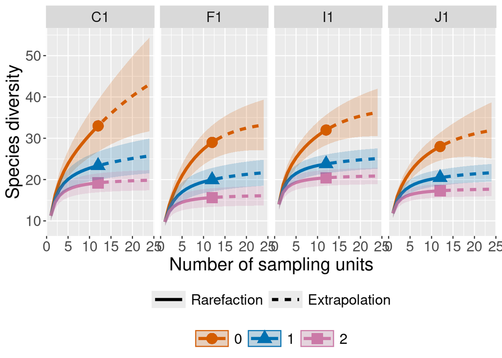

```r
## Orders of True Diversity
ggiNEXT(res_inext, type=1, facet.var="Assemblage")
```

In the plot above, the we can see one of the output graphs faceting plots and separating curves of each order of diversity `q` (0,1,2) where: * When q = 0, this is equivalent to species `richness` * When q = 1, this is equal to diversity of `common species` * When q = 2, this is equal to diverity of `dominant species`

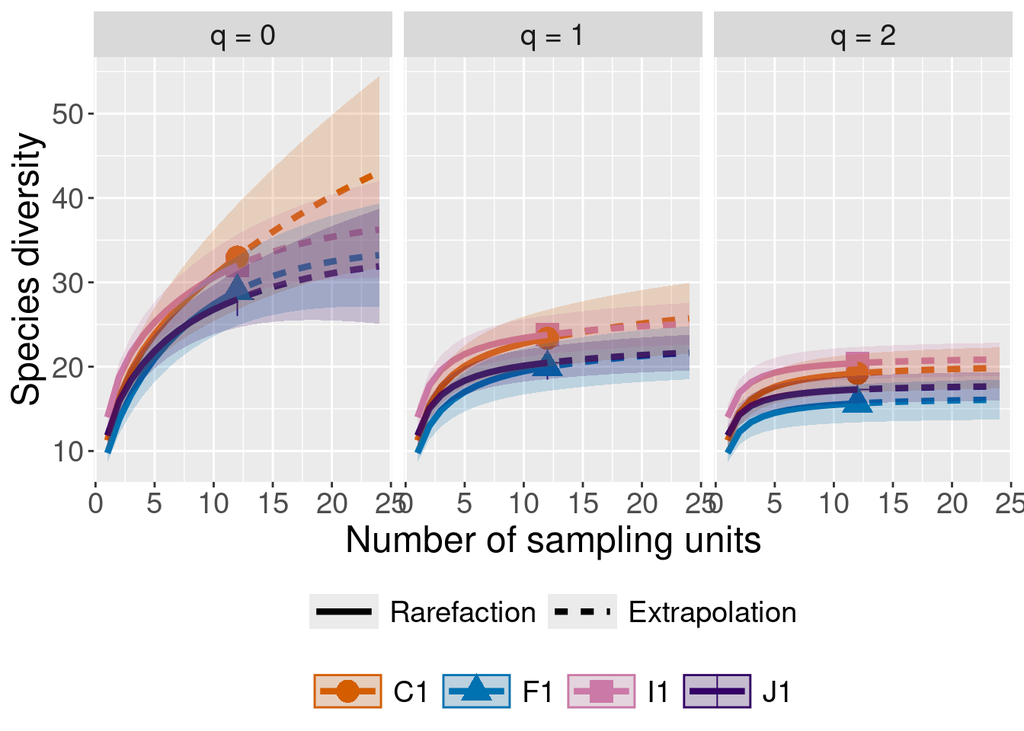

```r
ggiNEXT(res_inext, type=1, facet.var="Order.q", color.var="Assemblage")
```

The graph above is an inversion of the first, which I like more

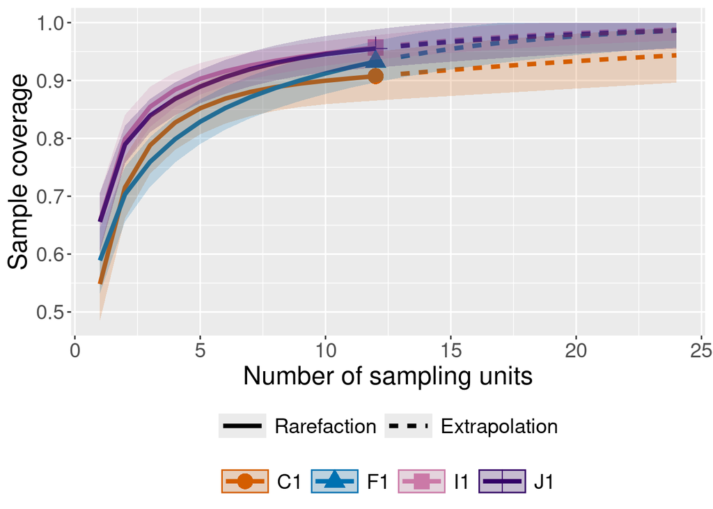

```r
## Sample coverage
ggiNEXT(res_inext,type=2, facet.var="None", color.var="Assemblage")
```

Here we have a clear otion that sample coverage (this means, sample effort) is good enough

## Alfa, beta and gamma diversities

### Overview of the communites (quadrat level)

```r
MC_q<-MetaCommunity(baseline_prop)
summary(MC_q)
```

```
Meta-community (class 'MetaCommunity') made of 3488 individuals in 48
communities and 52 species.

Its sample coverage is 0.999140320484051

Community weights are:
     C1.Q1      C1.Q2      C1.Q3      C1.Q4      C1.Q5      C1.Q6      C1.Q7
0.02083333 0.02083333 0.02083333 0.02083333 0.02083333 0.02083333 0.02083333
     C1.Q8      C1.Q9     C1.Q10     C1.Q11     C1.Q12      F1.Q1      F1.Q2
0.02083333 0.02083333 0.02083333 0.02083333 0.02083333 0.02083333 0.02083333
     F1.Q3      F1.Q4      F1.Q5      F1.Q6      F1.Q7      F1.Q8      F1.Q9
0.02083333 0.02083333 0.02083333 0.02083333 0.02083333 0.02083333 0.02083333
    F1.Q10     F1.Q11     F1.Q12      I1.Q1      I1.Q2      I1.Q3      I1.Q4
0.02083333 0.02083333 0.02083333 0.02083333 0.02083333 0.02083333 0.02083333
     I1.Q5      I1.Q6      I1.Q7      I1.Q8      I1.Q9     I1.Q10     I1.Q11
0.02083333 0.02083333 0.02083333 0.02083333 0.02083333 0.02083333 0.02083333
    I1.Q12      J1.Q1      J1.Q2      J1.Q3      J1.Q4      J1.Q5      J1.Q6
0.02083333 0.02083333 0.02083333 0.02083333 0.02083333 0.02083333 0.02083333
     J1.Q7      J1.Q8      J1.Q9     J1.Q10     J1.Q11     J1.Q12
0.02083333 0.02083333 0.02083333 0.02083333 0.02083333 0.02083333
Community sample numbers of individuals are:
 C1.Q1  C1.Q2  C1.Q3  C1.Q4  C1.Q5  C1.Q6  C1.Q7  C1.Q8  C1.Q9 C1.Q10 C1.Q11
  59.0   39.5   56.0   44.0   54.0   30.5   30.0   49.0   47.5   69.5   73.0
C1.Q12  F1.Q1  F1.Q2  F1.Q3  F1.Q4  F1.Q5  F1.Q6  F1.Q7  F1.Q8  F1.Q9 F1.Q10
  52.5   48.5   52.5   76.0   36.5   55.0   81.0  120.0   81.0   40.0  126.0
F1.Q11 F1.Q12  I1.Q1  I1.Q2  I1.Q3  I1.Q4  I1.Q5  I1.Q6  I1.Q7  I1.Q8  I1.Q9
  70.5   58.5   46.5   58.5   87.0   93.5  104.0   82.0   79.5   46.0   90.5
I1.Q10 I1.Q11 I1.Q12  J1.Q1  J1.Q2  J1.Q3  J1.Q4  J1.Q5  J1.Q6  J1.Q7  J1.Q8
 120.0   67.0   49.5   78.0   98.0   39.5   84.5   88.0   89.0  129.5  137.0
 J1.Q9 J1.Q10 J1.Q11 J1.Q12
  99.5   59.0   89.0  123.0
Community sample coverages are:
 C1.Q1  C1.Q2  C1.Q3  C1.Q4  C1.Q5  C1.Q6  C1.Q7  C1.Q8  C1.Q9 C1.Q10 C1.Q11
     1      1      1      1      1      1      1      1      1      1      1
C1.Q12  F1.Q1  F1.Q2  F1.Q3  F1.Q4  F1.Q5  F1.Q6  F1.Q7  F1.Q8  F1.Q9 F1.Q10
     1      1      1      1      1      1      1      1      1      1      1
F1.Q11 F1.Q12  I1.Q1  I1.Q2  I1.Q3  I1.Q4  I1.Q5  I1.Q6  I1.Q7  I1.Q8  I1.Q9
     1      1      1      1      1      1      1      1      1      1      1
I1.Q10 I1.Q11 I1.Q12  J1.Q1  J1.Q2  J1.Q3  J1.Q4  J1.Q5  J1.Q6  J1.Q7  J1.Q8
     1      1      1      1      1      1      1      1      1      1      1
 J1.Q9 J1.Q10 J1.Q11 J1.Q12
     1      1      1      1
```

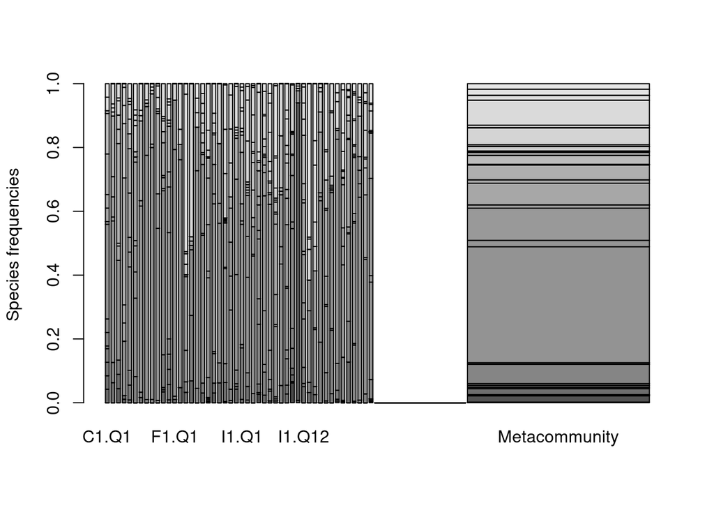

```r
plot(MC_q)
```

```r
divpart_q<-DivPart(q = 0, MC_q, Correction = "Best")
summary(divpart_q)
```

```
HCDT diversity partitioning of order 0 of metaCommunity MC_q

Alpha diversity of communities:
 C1.Q1  C1.Q2  C1.Q3  C1.Q4  C1.Q5  C1.Q6  C1.Q7  C1.Q8  C1.Q9 C1.Q10 C1.Q11
    16     11     12     10     14     13      8      6      7      9     14
C1.Q12  F1.Q1  F1.Q2  F1.Q3  F1.Q4  F1.Q5  F1.Q6  F1.Q7  F1.Q8  F1.Q9 F1.Q10
    15      5      5     10      7      6     14     14     12      6     14
F1.Q11 F1.Q12  I1.Q1  I1.Q2  I1.Q3  I1.Q4  I1.Q5  I1.Q6  I1.Q7  I1.Q8  I1.Q9
    11     13     15     15     14     15     16     16     17      8     15
I1.Q10 I1.Q11 I1.Q12  J1.Q1  J1.Q2  J1.Q3  J1.Q4  J1.Q5  J1.Q6  J1.Q7  J1.Q8
    16      6     15      8     10      9     11     12     10     15     14
 J1.Q9 J1.Q10 J1.Q11 J1.Q12
    17     10     12     14
Total alpha diversity of the communities:
[1] 11.70833
Beta diversity of the communities:
    None
4.441281
Gamma diversity of the metacommunity:
None
  52
```

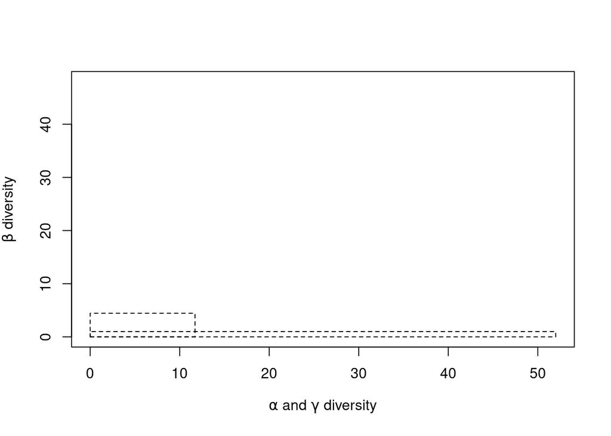

```r
plot(divpart_q)
```

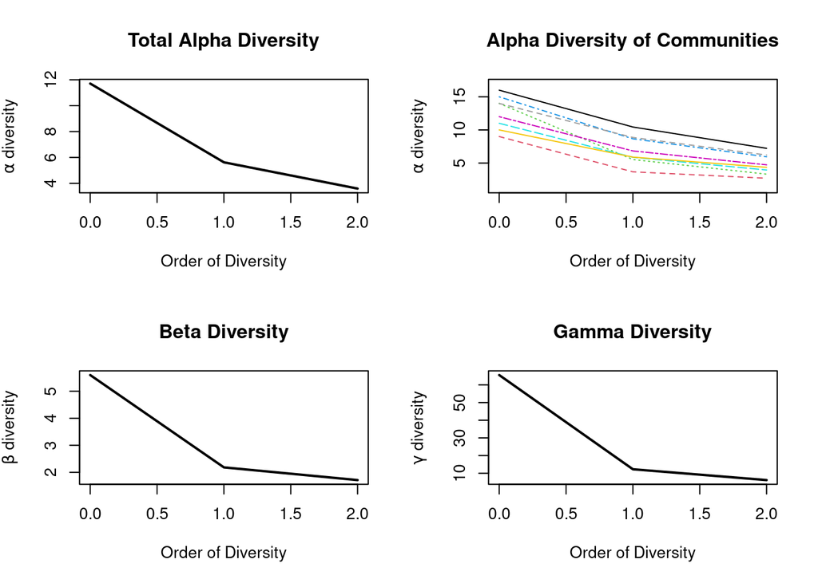

```r
dp_q <- DivProfile(seq(0, 2, 1), MC_q, Biased = FALSE, NumberOfSimulations = 0) ## Takes too long, only run once

plot(dp_q)
```

### Overview of the communites (plot level)

```r
MC_p<-MetaCommunity(baseline_prop_analyses)
summary(MC_p)
```

```
Meta-community (class 'MetaCommunity') made of 537.1785 individuals in 4
communities and 52 species.

Its sample coverage is 0.992488892248682

Community weights are:
  I1   J1   C1   F1
0.25 0.25 0.25 0.25
Community sample numbers of individuals are:
       I1        J1        C1        F1
185.76461 147.76086  92.56465 111.08838
Community sample coverages are:
       I1        J1        C1        F1
0.9897235 0.9934848 0.9697955 0.9922888
```

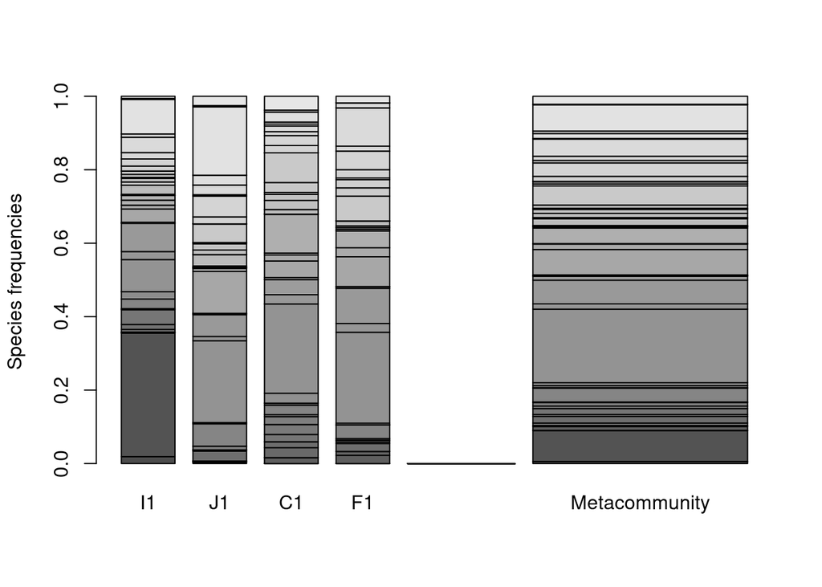

```r
plot(MC_p)
```

```r
divpart<-DivPart(q = 0, MC_p, Correction = "Best")
summary(divpart)
```

```
HCDT diversity partitioning of order 0 of metaCommunity MC_p

Alpha diversity of communities:
I1 J1 C1 F1
32 28 33 29
Total alpha diversity of the communities:
[1] 30.5
Beta diversity of the communities:
    None
1.704918
Gamma diversity of the metacommunity:
None
  52
```

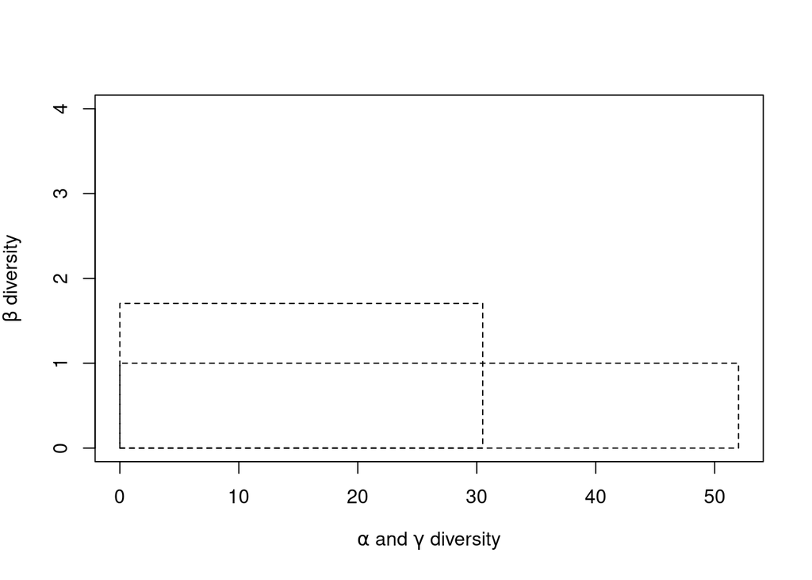

```r
plot(divpart)
```

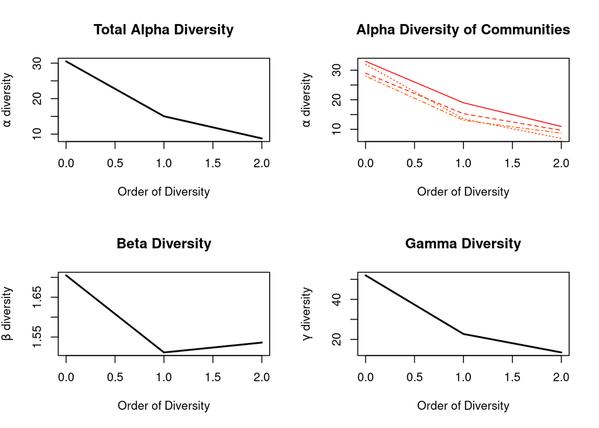

```r
dp_p <- DivProfile(seq(0, 2, 1), MC_p, Biased = FALSE, NumberOfSimulations = 0) # takes too long, only run once

plot(dp_p)
```

## Species composition NMDS

```r
base_nmds<-metaMDS(t(baseline_prop[,-1]))
```

```
Square root transformation
Wisconsin double standardization
*** Best solution repeated 1 times
```

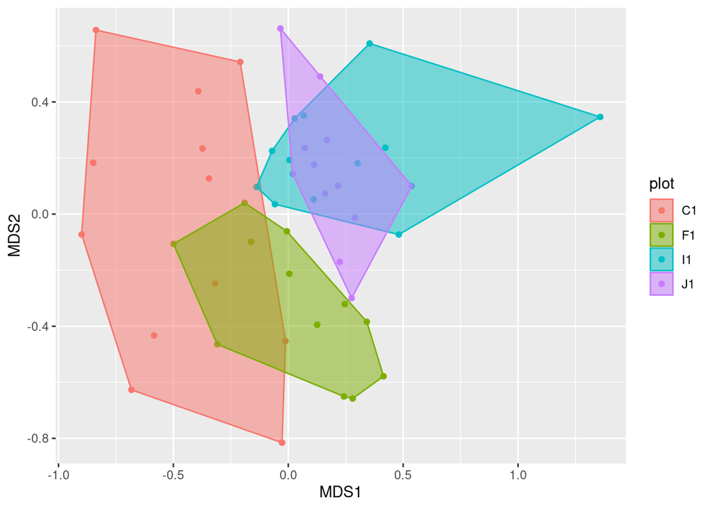

```r
nmds_res<-(base_nmds$points)
nmds_res %>%
  as.data.frame() %>%
  rownames_to_column() %>%
  mutate(plot=substr(rowname, 1,2))->nmds_res

hull <- nmds_res %>%
   group_by(plot) %>%
  slice(chull(MDS1, MDS2))
nmds_res %>%
  ggplot(aes(MDS1, MDS2, color=plot, fill=plot))+
  geom_point()+
  geom_polygon(data = hull, alpha = 0.5)
```

## Partition of Beta Diversity

```r
library(betapart)

p<-t(baseline_freq_raw[,-1])

beta_jac<-beta.multi(p, index.family="jac")
```

$beta.JTU **0.5882353** -> This is the amount of species turnover among the plots

$beta.JNE **0.03942428** -> This is the amount of nestedness among the plots

$beta.JAC  
**0.6276596** -> This is the total dissimilarity value among the plots

## Preliminary conclusions

1. Samples have in average the similar number of species
2. Species accumulation curve at the plot (10x10m) level stabilize for common (q=1) and dominant species (q=2) but is far from enough for rare species (q=0)
3. Methods seems adequate to capture diversity of plants at this scale
4. Species composition seem to vary a lot at this scale, suggesting underalaying factors such as: founding effects; inter-speciifc competition, etc…
5. Beta diversity is largely due to turnover of species, this suggesting that dispersal limitations and local-scale processes govern species assembly

## More to do…

### co-occurence of dominant species

```r
baseline_prop %>%
  # mutate(mean.abund = rowMeans(select(., where(is.numeric)))) %>%
  pivot_longer(!Species.name,names_to = "quadrants", values_to = "prop") %>%
  arrange(desc(prop)) %>%
  pivot_wider(names_from = Species.name, values_from = prop, values_fn = sum)->multi.corr

cor<-cor(multi.corr[,-1])

cor
```

[output not shown]

[output cut: 899 more lines]

[output not shown]